# Statistical inference with the GSS data

#student name: Valeriy Kondruk

## Setup

### Load packages

```r
library(ggplot2)
library(dplyr)
library(statsr)
library(descr) # library for the 'expected' table. you need a 'descr' package installed from CRAN
```

### Load data

```r
load("gss.Rdata")
```

## Part 1: Data

The General Social Survey data set includes 57,061 cases and 114 variables where each case represents one person. Data period spans from 1972 to 2012. There were no GSSs in 12 out of 41 years in the indicated period. The following plot shows the number of cases for each year along with the gaps when no GSSs were made.

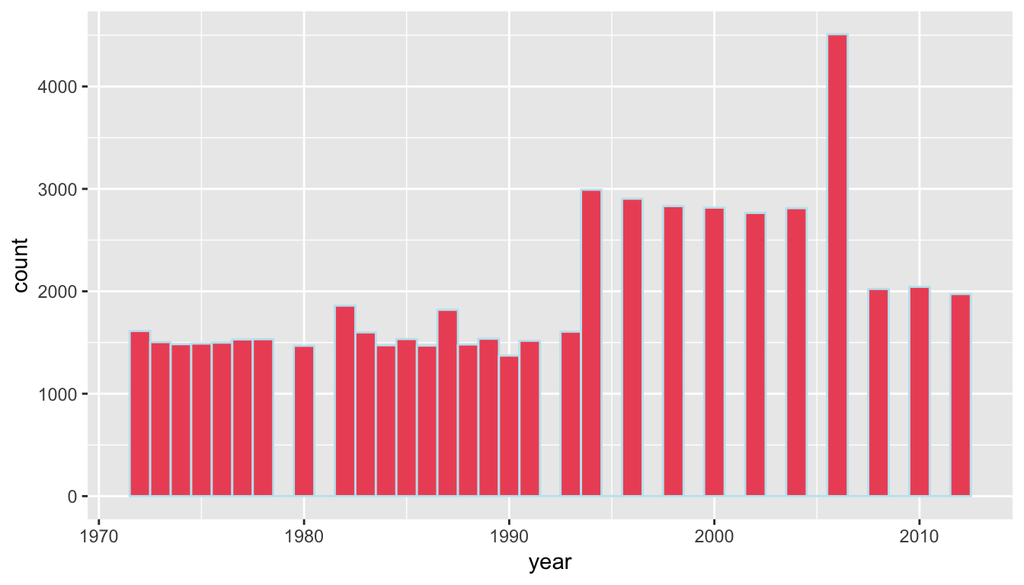

According to Appendix A: Sampling Design & Weighting to the GSS Guideline (http://gss.norc.org/Pages/Faq.aspx), the vast majority of GSS data is obtained in face-to-face interviews. Computer-assisted personal interviewing (CAPI) began in the 2002 GSS. Under some conditions when it has proved difficult to arrange an in-person interview with a sampled respondent, GSS interviews may be conducted by telephone.

The sampling methods had been changed several times in 41 years. The initial methodology used a “national stratified, multistage area probability sample of clusters of households in the continental United States”. However, the most recent sampling method used is a combination of stratified sampling, clustering, and multi-stage sampling. The sample is a multi-stage area probability sample to the block or segment level. At the block level, however, quota sampling is used with quotas based on sex, age, and employment status.

In the terms of this course, we deal with the **observational retrospective study** with **random sampling**. Thus, we can only make correlational conclusions in the following research. The correlation statement can be generalized to the whole population, though.

## Part 2: Research question

Among all of the variables presented in the survey, gun ownership bothers me the most. Gun violence is one of the major social problems in the United States. Mass shootings, gun-related homicide, and nonfatal injuries rates are extremely high. The United States easily ‘outperforms’ all high-income countries on gun-related deaths including homicides and suicides as well. Almost 40,000 deaths by firearms happened in the US in 2017 (almost 109 people died per day). A study conducted by the Journal of the American Medical Association in 2018, states that the worldwide gun death reach 250,000 Yearly and the United States is among just six countries that make up half of those fatalities. Two obvious explanatory factors are the accessibility of guns and lack of government control. Are there any personal factors that can explain such catastrophic rates?

I’m far from thinking that gun possession alone makes a person more likely to shoot someone or himself. However, not having a gun at all reduces one’s chances of being an initiator of a gun violence significantly.

Creating a ‘gun owner portrait’ might be the ultimate goal. But in this lab, I’m interested to find if certain political views could be the traits of a gun owner.

So the research question is: **Is a person affiliated with the Republican party more likely to own a gun than one affiliated with the Democratic party?**

## Part 3: Exploratory data analysis

First, that would be interesting to see a distribution of cases between different political groups. The following table shows the number of respondents for each variant of political self-identification:

```r
gss %>%
  group_by(partyid) %>%
  summarise(n())
```

```
## # A tibble: 9 x 2
##   partyid            `n()`
##   <fct>              <int>
## 1 Strong Democrat     9117
## 2 Not Str Democrat   12040
## 3 Ind,Near Dem        6743
## 4 Independent         8499
## 5 Ind,Near Rep        4921
## 6 Not Str Republican  9005
## 7 Strong Republican   5548
## 8 Other Party          861
## 9 <NA>                 327
```

Another interesting observation: there are fewer people on both extreme sides of a political specter than those in the middle (either not strong democrats or not strong republicans), 14,665 persons vs 21,045 persons.

Apparently, there were significant deviations in the above proportions during the different periods when the survey was made.

Let’s take a look at the distribution of gun owners among different political groups. The following table shows the number of cases for the gun owners (filtered by ‘owngun’ variable:

```r
gss %>%
  group_by(partyid) %>%
  filter(owngun == "Yes") %>%
  summarise(n())
```

```
## # A tibble: 9 x 2
##   partyid            `n()`
##   <fct>              <int>
## 1 Strong Democrat     1976
## 2 Not Str Democrat    2857
## 3 Ind,Near Dem        1497
## 4 Independent         1741
## 5 Ind,Near Rep        1416
## 6 Not Str Republican  2598
## 7 Strong Republican   1680
## 8 Other Party          181
## 9 <NA>                  54
```

We can see that the number of gun owners among dems is higher than among reps. However, remember that we have way more of democrats in this data set than we have republicans. We would need to compare proportions properly in the inference section.

The following heatmap shows the relationship between political self-identification and gun ownership.

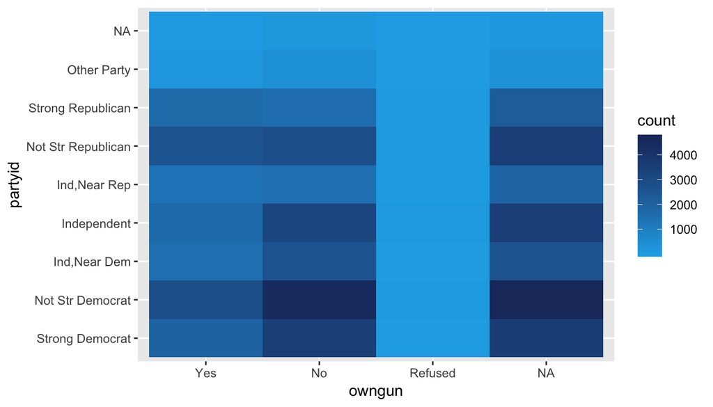

```r
gss %>%
  ggplot(aes(y = partyid, x = owngun)) +
  geom_bin2d() +
  scale_fill_gradient(low ="#1DACE8", high ="#1C366B")
```

Again, we can see that both strong dems and strong reps fall into the same bins. But considering differences in the number of dems and reps overall, we can’t make inference based just on this plot.

## Part 4: Inference

```r
# Using nested ifelse functions we mark the partyid responses with more strict definitions and put the output in a new variable 'party_strict'

gss_guns_party <- gss %>%
  mutate(party_strict = ifelse(partyid == "Strong Democrat" | partyid == "Not Str Democrat", "democrat", ifelse(partyid == "Strong Republican" | partyid == "Not Str Republican", "republican", ifelse(partyid == "Ind,Near Dem" | partyid == "Ind,Near Rep" | partyid == "Independent", "independent", ifelse(partyid == "Other Party", "other", NA)))))
```

Now we decreased the number of politic views options from 9 to 5 (including NAs). Here’s the counts summary:

```r
gss_guns_party %>%
  group_by(party_strict) %>%
  summarise(n())
```

```
## # A tibble: 5 x 2
##   party_strict `n()`
##   <chr>        <int>
## 1 <NA>           327
## 2 democrat     21157
## 3 independent  20163
## 4 other          861
## 5 republican   14553
```

Then, we want to clean up the data by removing NAs from both party_strict and owngun variables. Note that the ‘Refused’ responses are also eliminated as we’re not interested in those cases.

```r
guns_party_clean <- gss_guns_party %>%
  filter(!is.na(party_strict)) %>%
  mutate(owngun = ifelse(owngun == "Refused", NA, ifelse(owngun == "No", "No", ifelse(owngun == "Yes", "Yes", NA)))) %>%
  filter(!is.na(owngun))
# I used this mutate plus nested ifelse construction here to wipe out 'Refused' somehow. When I used simple filter a 'Refused' response remained in the contingency table even though it had 0 reported cases. I couldn't solve this issue with other methods.

gp_table <- table(guns_party_clean$party_strict, guns_party_clean$owngun)
gp_table
```

```
##
##                 No  Yes
##   democrat    7966 4833
##   independent 7300 4654
##   other        348  181
##   republican  4396 4278
```

### Chi-square test of independence

It’s time to find out whether political party identification and gun ownership are dependent. To do so, we build two hypotheses:

- H<sub>0</sub>: Political party affiliation and gun ownership are independent.
- H<sub>A</sub>: Political party affiliation and gun ownership are dependent.

We want to take a Chi-square test. To do so, we would need to calculate the expected counts for each case and compare them to the observed values. While some sampling variation is expected, we would expect a test statistic to closely follow a chi-square distribution.

Build a contingency table with the observed counts (values shown above) and expected counts (values shown below) first:

```r
CrossTable(gp_table, prop.r = FALSE, prop.c = FALSE, prop.t = FALSE,
    prop.chisq = FALSE, expected = TRUE)
```

```
##    Cell Contents
## |-------------------------|
## |                       N |
## |              Expected N |
## |-------------------------|
##
## ======================================
##                    No      Yes   Total
## --------------------------------------
## democrat         7966     4833   12799
##                7542.3   5256.7
## --------------------------------------
## independent      7300     4654   11954
##                7044.4   4909.6
## --------------------------------------
## other             348      181     529
##                 311.7    217.3
## --------------------------------------
## republican       4396     4278    8674
##                5111.5   3562.5
## --------------------------------------
## Total           20010    13946   33956
## ======================================
```

Checking conditions for the Chi-square test * Independence - *passed* + a random sampling was used for this survey + each case that contributes a count to the table is independent of all the other cases in the table * Sample size - *passed* + each particular scenario (i.e. cell) has easily over 5 expected cases * Degrees of freedom > 1 - *passed* + we have df = (Rows - 1) x (Columns - 1) = 3 x 1 = 3

Let’s run an inference function to test our hypotheses with party affiliation (*party_strict*) being an explanatory variable and gun ownership (*owngun*) being a response variable.

```r
inference(y = owngun, data = guns_party_clean, x = party_strict, statistic = "proportion", type= "ht", method = "theoretical", success = "Yes", alternative = "greater", sig_level = 0.05)
```

```
## Response variable: categorical (2 levels)
## Explanatory variable: categorical (4 levels)
## Observed:
##              y
## x               No  Yes
##   democrat    7966 4833
##   independent 7300 4654
##   other        348  181
##   republican  4396 4278
##
## Expected:
##              y
## x                    No       Yes
##   democrat    7542.3486 5256.6514
##   independent 7044.3969 4909.6031
##   other        311.7355  217.2645
##   republican  5111.5190 3562.4810
##
## H0: party_strict and owngun are independent
## HA: party_strict and owngun are dependent
## chi_sq = 334.6637, df = 3, p_value = 0
```

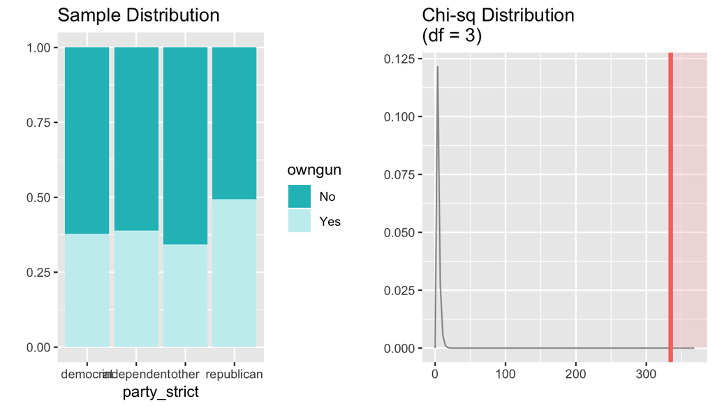

*Plot on the left shows a Sample distribution* The proportion of gun owners among republicans is higher than such proportion for all other political views groups.

*Plot on the right shows a Chi-square distribution for 3 degrees of freedom* The shaded area represents the p-value.

With the test statistic of 334.66, the significance level of 0.05, and the p-value very close to zero, we can reject the null hypothesis as data provide convincing evidence that party affiliation and gun ownership are in fact dependent. It appears that gun ownership varies by political views.

### Difference in two proportions

We found out that political affiliation and gun ownership are in fact dependent. Now we can answer our research question wether a republican is more likely to own a gun than a democrat.

What is an appropriate set of hypotheses for this study? Let p_r represent the proportion of republicans possesing guns and p_d represent the proportion of democrats owning guns.

We’re interested in wheter republicans are more likely to own a gun, so a one-sided test is appropriate.

- H<sub>0</sub>: Republicans are as likely to own a gun as democrats. p<sub>r</sub> - p<sub>d</sub> = 0
- H<sub>A</sub>: Republicans are more likely to own a gun than democrats. p<sub>r</sub> - p<sub>d</sub> > 0

Let’s filter our data set to be able to deal with these two political groups only:

```r
rep_dem_only <- guns_party_clean %>%
  filter(party_strict == "republican" | party_strict == "democrat")
```

The following table shows the number of observations for each pair of political affiliation and gun ownership variables.

```r
rep_dem_table <- table(rep_dem_only$party_strict, rep_dem_only$owngun)
rep_dem_table <- rep_dem_table[2:1, 2:1]
rep_dem_table
```

```
##
##               Yes   No
##   republican 4278 4396
##   democrat   4833 7966
```

Let’s find out the observed gun ownership rates for republicans and democrats:

```r
rep_dem_rates <- prop.table(rep_dem_table, margin = 1)
rep_dem_rates
```

```
##
##                    Yes        No
##   republican 0.4931981 0.5068019
##   democrat   0.3776076 0.6223924
```

```r
point_estimate <- rep_dem_rates[1,1] - rep_dem_rates[2,1]
```

Table above shows that around 37.8% of persons considering themselves democrats own guns (p<sub>d</sub> = 0.3776076). Observed rate for republicans possesing a gun is 49.3% (p<sub>r</sub> = 0.4931981).

Observed difference: $\hat{p}$<sub>r</sub> - $\hat{p}$<sub>d</sub> = 0.4931981 - 0.3776076 = 0.1155904. Which means that the rate of gun ownership among republicans is over 11% higher than among democrats. Could this difference be explainable by chance?

The following function compares two proportions RepOwnGun/TotalRep to DemOwnGun/TotalDem to find if the difference between them is statistically significant at a 95% confidence level.

```r
rep_vs_dem_inference <- inference(rep_dem_only, y = owngun, x = party_strict, type = "ht", statistic = "proportion", method = "theoretical", alternative = "less", conf_level = 0.95, success = "Yes", null = 0)
```

```
## Response variable: categorical (2 levels, success: Yes)
## Explanatory variable: categorical (2 levels)
## n_democrat = 12799, p_hat_democrat = 0.3776
## n_republican = 8674, p_hat_republican = 0.4932
## H0: p_democrat =  p_republican
## HA: p_democrat < p_republican
## z = -16.8166
## p_value = < 0.0001
```

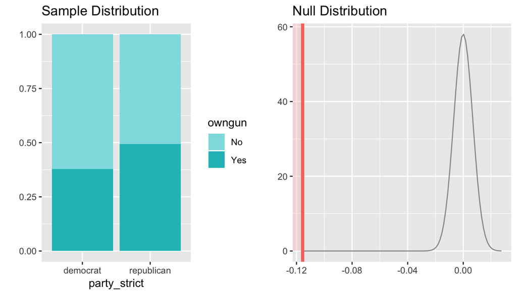

With the test statistics of Z=-16.8166159 we have a p-value of 9.219760810^{-64} which is very close to zero and less than the confidence level. **This p-value provides convincing evidence against the null hypothesis**. If the null hypothesis was, in fact, correct and the rate of gun ownership among republicans is the same as one for democrats, the probability of observing an 11.6% or higher difference in those rates is very close to zero. Thus, **Republicans are more likely to own a gun than Democrats**.

### Confidence intervals

It’s clear now that **partisanship and gun ownership are dependent** and that Republicans are more likely to own guns than Democrats. But how high is this likelihood?

The survey shows an 11.6% difference for this particular sample of respondents. The true difference for the entire population of the United States might be different. We can build a confidence interval to see the range in which the true population parameter for this difference would fall.

Using a confidence interval formula *point estimate* ± $z^{*}$ * SE, we come up with the following interval at a 95% confidence level:

```r
left <- point_estimate-qnorm(0.975)*rep_vs_dem_inference$SE
right <- point_estimate+qnorm(0.975)*rep_vs_dem_inference$SE

left
```

```
## [1] 0.1021185
```

```r
right
```

```
## [1] 0.1290624
```

Otherwise, we can use the following function to test of equal or given proportions with very similar results:

```r
prop.test(rep_dem_table, conf.level = 0.95, alternative = "two.sided")
```

```
##
##  2-sample test for equality of proportions with continuity
##  correction
##
## data:  rep_dem_table
## X-squared = 282.33, df = 1, p-value < 2.2e-16
## alternative hypothesis: two.sided
## 95 percent confidence interval:
##  0.1020314 0.1291495
## sample estimates:
##    prop 1    prop 2
## 0.4931981 0.3776076
```

We are **95% confident** that the population (here, the entire population of the US) rate of gun ownership for republicans is between **10.2% and 12.9%** higher than one for democrats.

As the 0% difference doesn’t fall into this interval, we conclude that there’s in fact difference for the proportions of party affiliation and gun ownership views. This perfectly matches the findings of the hypothesis test above.

## Conclusion

Data of the survey show that political views indeed correlate with gun ownership in the USA. Answering the research question, we found out that people affiliated with the republican party are 10.2% to 12.9% more likely to own a gun than those who belong to the democratic party.

For future research, that would be interesting to know if this difference has been changing significantly over time and what its current rate.